# Machine-Learning-vol.04-多項式回帰

## 4.1 多項式モデル

多項式回帰とは､その名の通り**多項式（2次関数や3次関数など）を利用した回帰分析**のことです｡これにより､**回帰式を曲線（あるいは曲面､超曲面）にすることができます（｢非線形性を導入する｣といいます）**｡

2､3章で扱った線形回帰のモデルでは､目的変数と説明変数との間に直線的な関係があることを前提にしていました｡しかし､変数間の関係が曲線的になっていることも､もちろんあります｡実際､**前回の重回帰分析で扱ったBostonデータのLSTATは､目的変数であるMEDVと曲線的な関係にありました**｡前回はこれを無理やり線形回帰に持ち込みましたが､当然､曲線で柔軟にフィットさせたほうが､より当てはまりの良いモデルになります｡今回は､前回のBostonデータ分析の延長で､**非線形性を導入することによって予測性能が上がるのかを検証してみましょう**｡

[figure not shown]

多項式とは､2次関数や3次関数のような**高次の関数も含めた関数**を指し､以下の式で一般化できます｡

$$y = w_0 + w_1x + w_2x^2 + … + w_dx^d$$

### 4.1.1 線形基底関数モデル

線形基底関数モデルとは､**変数変換によって拡張された線形モデル**です｡実は､**多項式回帰も線形モデルにひと工夫加えるだけで実行できます**｡下の式を見ていただければわかるかと思うのですが､ **$x_1^2$ や $x_1^3$ を説明変数のひとつと見なせば､多項式モデルも線形モデルと何ら変わらない構造なのです**｡ $x_1$ から $x_1^2$ や $x_1^3$ という変数をつくりさえすれば､あとは線形回帰と全く同じ方法で学習できます｡

[figure not shown]

### 4.1.2 基底関数

基底関数とは､**線形モデルを拡張するための変数変換を行う関数**です｡基底関数には代表的なものがいくつもありますが､今回は以下に表す**多項式基底**の基底関数を利用します｡やっていることは特に難しくなく､**与えられた変数の累乗を計算して返しているだけ**です｡これを利用して､LSTATについて2次関数や3次関数で回帰できるようになります｡

$$\Phi(x_j) = x^j$$

[figure not shown]

## 4.2 単一変数での実装と比較

## 動画リンク: 多項式回帰②

早速､この多項式回帰を実装していきましょう｡比較のために､線形回帰による分析も行い､**自由度調整済み決定係数**を比較してみたいと思います｡まずは､**LSTATのみを用いた回帰を行います**｡こちらであれば**平面の可視化が可能なので､線形と非線形の場合でフィット度合いを比較しやすくなります**｡この後で､RMまでを含めた比較を行いましょう｡

```python
# 必要なライブラリのインポート
import numpy as np
import pandas as pd
import matplotlib.pyplot as plt
% matplotlib inline
```

#### データの読み込み

```python
# データセットを読み込み
from sklearn.datasets import load_boston # bostonデータを格納したクラス
boston = load_boston()                   # インスタンスを生成
```

```python
# DataFrameを生成
df_data = pd.DataFrame(boston.data, columns=boston.feature_names)
df_target = pd.DataFrame(boston.target, columns=['MEDV'])
df = pd.concat([df_data, df_target], axis=1)
df.head()
```

|  | CRIM | ZN | INDUS | CHAS | NOX | RM | AGE | DIS | RAD | TAX | PTRATIO | B | LSTAT | MEDV |
| --- | --- | --- | --- | --- | --- | --- | --- | --- | --- | --- | --- | --- | --- | --- |
| 0 | 0.00632 | 18.0 | 2.31 | 0.0 | 0.538 | 6.575 | 65.2 | 4.0900 | 1.0 | 296.0 | 15.3 | 396.90 | 4.98 | 24.0 |
| 1 | 0.02731 | 0.0 | 7.07 | 0.0 | 0.469 | 6.421 | 78.9 | 4.9671 | 2.0 | 242.0 | 17.8 | 396.90 | 9.14 | 21.6 |
| 2 | 0.02729 | 0.0 | 7.07 | 0.0 | 0.469 | 7.185 | 61.1 | 4.9671 | 2.0 | 242.0 | 17.8 | 392.83 | 4.03 | 34.7 |
| 3 | 0.03237 | 0.0 | 2.18 | 0.0 | 0.458 | 6.998 | 45.8 | 6.0622 | 3.0 | 222.0 | 18.7 | 394.63 | 2.94 | 33.4 |
| 4 | 0.06905 | 0.0 | 2.18 | 0.0 | 0.458 | 7.147 | 54.2 | 6.0622 | 3.0 | 222.0 | 18.7 | 396.90 | 5.33 | 36.2 |

```python
# 特徴量を抽出
lstat = df.loc[:, ['LSTAT']].values
rm = df.loc[:, ['RM']].values
y = df.loc[:, ['MEDV']].values
```

### 4.2.1 線形回帰

まずは､線形回帰で学習させます｡つまりは､**LSTATによる単回帰**です｡

#### 線形回帰モデルで学習

```python
# ホールド・アウト法によるデータの分割
# random_stateを0に固定してあるので､毎回同じサンプルに分割
from sklearn.model_selection import train_test_split
lstat_train, lstat_test, y_train, y_test = train_test_split(lstat, y, test_size = 0.3, random_state = 0)
```

```python
# 線形回帰のモデルを学習させる
from sklearn.linear_model import LinearRegression
model_lin = LinearRegression()
model_lin.fit(lstat_train, y_train)
```

```
LinearRegression(copy_X=True, fit_intercept=True, n_jobs=1, normalize=False)
```

#### 回帰式のプロット

**線形回帰の学習結果を散布図に当てはめてみましょう**｡最小二乗法を利用しているので､直線としては当てはまりは悪くありません｡しかし､**どうしても直線では表現力に限界があることがわかります**｡

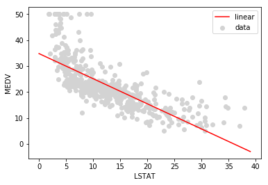

```python
# 散布図に近似直線を重ねてみる
plt.scatter(lstat, y, color='lightgray', label='data')         # 散布図を表示
x = np.arange(0, 40, 1)[:, np.newaxis]                         # プロットのためのxを用意
plt.plot(x, model_lin.predict(x), color='red', label='linear') # 回帰直線を表示
plt.xlabel('LSTAT')                                            # x軸のラベルを表示
plt.ylabel('MEDV')                                             # y軸のラベルを表示
plt.legend(loc = 'upper right')                                # 凡例を表示
plt.show()                                                     # 上記の内容でグラフを表示
```

### 4.2.2 多項式回帰（2次関数）

続いて､多項式回帰で学習させます｡まずは**2次関数（quadratic function）**による回帰を行います｡

#### 変数変換

多項式基底の基底関数によって変数変換を行います｡多項式基底はscikit-learnの**PolynomialFeatures**クラスで生成できます｡引数の**degree**を指定することで､任意の次数の多項式基底をつくり､その後､**fit_traisform()**メソッドで変数変換を実行します｡

```python
# 2次関数の変数変換
from sklearn.preprocessing import PolynomialFeatures
quad = PolynomialFeatures(degree=2)    # 2次の多項式規定を生成
lstat_quad = quad.fit_transform(lstat) # 生成した基底関数で変数変換を実行
lstat_quad
```

```
array([[  1.    ,   4.98  ,  24.8004],
       [  1.    ,   9.14  ,  83.5396],
       [  1.    ,   4.03  ,  16.2409],
       ...,
       [  1.    ,   5.64  ,  31.8096],
       [  1.    ,   6.48  ,  41.9904],
       [  1.    ,   7.88  ,  62.0944]])
```

#### 2次関数のモデルで学習

```python
# ホールド・アウト法によるデータの分割
# random_stateを0に固定してあるので､毎回同じサンプルに分割
lstat_quad_train, lstat_quad_test, _, _ = train_test_split(lstat_quad, y, test_size = 0.3, random_state = 0)
```

```python
# 線形回帰のインスタンスを生成
model_quad = LinearRegression()

# 変換後の変数を利用して実行
model_quad.fit(lstat_quad_train, y_train)
```

```
LinearRegression(copy_X=True, fit_intercept=True, n_jobs=1, normalize=False)
```

#### 回帰式のプロット

多項式回帰によって､当てはまりが良くなっていることをグラフによる比較で確認します｡

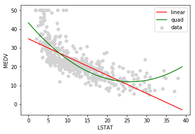

```python
# 散布図に近似直線､近似曲線を重ねてみる
plt.scatter(lstat, y, color='lightgray', label='data')               # 散布図を表示
plt.plot(x, model_lin.predict(x), color='red', label='linear')       # 回帰直線を表示
x_quad = quad.fit_transform(x)                                       # プロットのためのxも2変数変換する
plt.plot(x, model_quad.predict(x_quad), color='green', label='quad') # 回帰曲線を表示（2次関数）
plt.xlabel('LSTAT')                                                  # x軸のラベルを表示
plt.ylabel('MEDV')                                                   # y軸のラベルを表示
plt.legend(loc = 'upper right')                                      # 凡例を表示
plt.show()                                                           # 上記の内容でグラフを表示
```

### 4.2.3 多項式回帰（3次関数）

続いて､更に次数を上げて**3次関数（cubic function）**による回帰を行います｡

#### 変数変換

```python
# 3次関数の変数変換
cubic = PolynomialFeatures(degree=3)     # 3次の多項式規定を生成
lstat_cubic = cubic.fit_transform(lstat) # 生成した基底関数で変数変換を実行
lstat_cubic
```

```
array([[   1.      ,    4.98    ,   24.8004  ,  123.505992],
       [   1.      ,    9.14    ,   83.5396  ,  763.551944],
       [   1.      ,    4.03    ,   16.2409  ,   65.450827],
       ...,
       [   1.      ,    5.64    ,   31.8096  ,  179.406144],
       [   1.      ,    6.48    ,   41.9904  ,  272.097792],
       [   1.      ,    7.88    ,   62.0944  ,  489.303872]])
```

#### 3次関数のモデルで学習

```python
# ホールド・アウト法による分割
lstat_cubic_train, lstat_cubic_test, _, _ = train_test_split(lstat_cubic, y, test_size = 0.3, random_state = 0)
```

```python
# 線形回帰のインスタンスを生成
model_cubic = LinearRegression()

# 変換後の変数を利用して実行
model_cubic.fit(lstat_cubic_train, y_train)
```

```
LinearRegression(copy_X=True, fit_intercept=True, n_jobs=1, normalize=False)
```

#### 回帰式をプロット

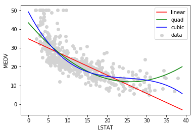

```python
# 散布図に近似直線､近似曲線を重ねてみる
plt.scatter(lstat, y, color='lightgray', label='data')                 # 散布図を表示
plt.plot(x, model_lin.predict(x), color='red', label='linear')         # 回帰直線を表示
plt.plot(x, model_quad.predict(x_quad), color='green', label='quad')   # 回帰曲線を表示（2次関数）
x_cubic = cubic.fit_transform(x)                                       # プロットのためのxも2変数変換する
plt.plot(x, model_cubic.predict(x_cubic), color='blue', label='cubic') # 回帰曲線を表示（2次関数）
plt.xlabel('LSTAT')                                                    # x軸のラベルを表示
plt.ylabel('MEDV')                                                     # y軸のラベルを表示
plt.legend(loc = 'upper right')                                        # 凡例を表示
plt.show()                                                             # 上記の内容でグラフを表示
```

### 4.2.4 自由度調整済み決定係数の比較

グラフによって､多項式回帰の方が当てはまりが良さそうだということがわかりました｡次に､それを定量的に確認するために**自由度調整済み決定係数**を比較してみます｡

```python
# 自由度調整済み決定係数
# (決定係数, trainまたはtestのサンプル数, 利用した特徴量の数)
def adjusted(score, n_sample, n_features):
    adjusted_score = 1 - (1 - score) * ((n_sample - 1) / (n_sample - n_features - 1))
    return adjusted_score
```

```python
# 自由度調整済み決定係数をtrainとtestに分けて出力
print('adjusted R^2')
print('')

# 線形回帰
print('model_linear')
print('train: %.3f' % adjusted(model_lin.score(lstat_train, y_train), len(y_train), 1))
print('test : %.3f' % adjusted(model_lin.score(lstat_test, y_test), len(y_test), 1))
print('')

# 2次関数
print('model_quad')
print('train: %.3f' % adjusted(model_quad.score(lstat_quad_train, y_train), len(y_train), 2))
print('test : %.3f' % adjusted(model_quad.score(lstat_quad_test, y_test), len(y_test), 2))
print('')

# 3次関数
print('model_cubic')
print('train: %.3f' % adjusted(model_cubic.score(lstat_cubic_train, y_train), len(y_train), 3))
print('test : %.3f' % adjusted(model_cubic.score(lstat_cubic_test, y_test), len(y_test), 3))
```

```
adjusted R^2

model_linear
train: 0.551
test : 0.519

model_quad
train: 0.656
test : 0.591

model_cubic
train: 0.672
test : 0.607
```

3者を比べてみると､やはり**多項式回帰の方が当てはまりは良いことがわかりました**｡また､**2次関数と3次関数の間にはそれほど大きな開きはありませんでした**｡

## 4.3 複数変数での実装と比較

## 動画リンク: 多項式回帰③

次に､前回と同じようにLSTATに加えて**RMも利用して**分析を行います｡このとき､多項式回帰のモデルは重回帰と同じ扱いができますので､**単純に説明変数にRMを加えるだけで実装できます**｡説明変数の接続は､**np.hstack()**で行うことができます｡

[figure not shown]

### 4.3.1 線形回帰

まずは､線形回帰です｡重回帰のときと全く同じ学習になります｡

```python
# LSTAT（1次）にRMを加える
X_lin = np.hstack((lstat, rm))
```

```python
# ホールド・アウト法によるデータの分割
X_lin_train, X_lin_test, _, _ = train_test_split(X_lin, y, test_size = 0.3, random_state = 0)
# 線形回帰による学習
model_lin_2 = LinearRegression()
model_lin_2.fit(X_lin_train, y_train)
```

```
LinearRegression(copy_X=True, fit_intercept=True, n_jobs=1, normalize=False)
```

### 4.3.2 多項式回帰（2次関数）

```python
# LSTAT（2次）にRMを加える
X_quad = np.hstack((lstat_quad, rm))
```

```python
# ホールド・アウト法によるデータの分割
X_quad_train, X_quad_test, _, _ = train_test_split(X_quad, y, test_size = 0.3, random_state = 0)
# 線形回帰による学習
model_quad_2 = LinearRegression()
model_quad_2.fit(X_quad_train, y_train)
```

```
LinearRegression(copy_X=True, fit_intercept=True, n_jobs=1, normalize=False)
```

### 4.3.3 多項式回帰（3次関数）

```python
# LSTAT（3次）にRMを加える
X_cubic = np.hstack((lstat_cubic, rm))
```

```python
# ホールド・アウト法によるデータの分割
X_cubic_train, X_cubic_test, _, _ = train_test_split(X_cubic, y, test_size = 0.3, random_state = 0)
# 線形回帰による学習
model_cubic_2 = LinearRegression()
model_cubic_2.fit(X_cubic_train, y_train)
```

```
LinearRegression(copy_X=True, fit_intercept=True, n_jobs=1, normalize=False)
```

### 4.3.4 自由度調整済み決定係数の比較

```python
# 自由度調整済み決定係数をtrainとtestに分けて出力
print('adjusted R^2')
print('')

# 線形回帰
print('model_linear_2')
print('train: %.3f' % adjusted(model_lin_2.score(X_lin_train, y_train), len(y_train), 2))
print('test : %.3f' % adjusted(model_lin_2.score(X_lin_test, y_test), len(y_test), 2))
print('')

# 2次関数
print('model_quad_2')
print('train: %.3f' % adjusted(model_quad_2.score(X_quad_train, y_train), len(y_train), 3))
print('test : %.3f' % adjusted(model_quad_2.score(X_quad_test, y_test), len(y_test), 3))
print('')

# 3次関数
print('model_cubic_2')
print('train: %.3f' % adjusted(model_cubic_2.score(X_cubic_train, y_train), len(y_train), 4))
print('test : %.3f' % adjusted(model_cubic_2.score(X_cubic_test, y_test), len(y_test), 4))
```

```
adjusted R^2

model_linear_2
train: 0.649
test : 0.602

model_quad_2
train: 0.726
test : 0.630

model_cubic_2
train: 0.728
test : 0.628
```

以上の結果より､**RMを含めた学習でも多項式回帰の方が性能が良くなることがわかりました**｡また､RMを含めた場合でも､**2次関数と3次関数の場合には､予測性能にほとんど差がないようです**｡実用の際にはどちらのモデルを利用してもいいでしょう｡

### 4.3.5 残差プロットの比較

また､残差プロットを比較しても面白いことがわかります｡前回､残差の発生傾向のところで､**プロットが山なりのカーブを描いていたこと**には触れませんでした｡実は､あのカーブは**線形回帰がLSTATの曲線的な傾向を無視していたために生まれていたものだったのです**｡多項式回帰の残差プロットでは､**そのカーブが吸収されて､残差0の線の周囲により良くまとまっていることがわかります**｡

```python
# 残差プロットを行う関数を定義
def res_plot(y_train, y_train_pred, y_test, y_test_pred):
    # train, testごとに残差を算出
    res_train = y_train_pred - y_train
    res_test  = y_test_pred - y_test

    # train, testごとに(予測値, 残差)をプロット
    plt.figure(figsize=(8, 8))
    plt.scatter(y_train_pred, res_train, color='blue', marker='o', label='train', alpha=0.5)
    plt.scatter(y_test_pred, res_test, color='green', marker='s', label='test', alpha=0.5)

    plt.xlabel('Predicted Values')                  # x軸のラベルを表示
    plt.ylabel('Residuals')                         # y軸のラベルを表示
    plt.legend(loc='upper left')                    # 凡例を左上に表示
    plt.hlines(y=0, xmin=-10, xmax=50, color='red') # 残差0の線を表示
    plt.xlim([-10, 50])                             # 表示する横軸の範囲を指定
    plt.show()
```

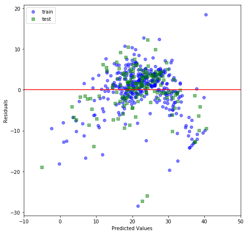

```python
# 残差プロットを出力
# 線形回帰の場合
res_plot(y_train, model_lin_2.predict(X_lin_train), y_test, model_lin_2.predict(X_lin_test))
```

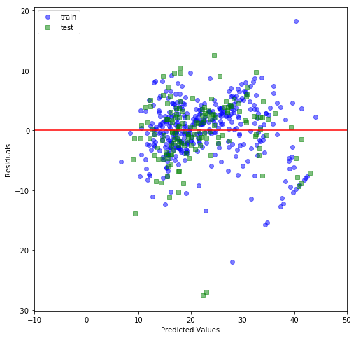

```python
# 残差プロットを出力
# 多項式回帰（3次関数の場合）
res_plot(y_train, model_cubic_2.predict(X_cubic_train), y_test, model_cubic_2.predict(X_cubic_test))
```

## 4.4 過学習とのトレードオフ

## 動画リンク: 多項式回帰④

多項式回帰は､**線形回帰よりも柔軟なフィッティングを可能にします**｡しかし､その反面､**柔軟さは過学習のしやすさにもなります**｡極端な話､**次数を大きくしていけば行くほどモデルの柔軟さが増し､trainデータへの当てはまりはどんどん良くなっていきます**｡しかし､**そのとき必ずしもtestデータへの当てはまりがいいとは限りません**｡重回帰のときの繰り返しになりますが､教師あり学習で大事なのは**将来のデータへの予測性能**です｡なので､むやみに次数を上げることは､あまり好ましいことではありません｡必ず､**testデータの自由度調整済み決定係数を基準に**､ある程度の次数にとどめるようにしてください｡

[figure not shown]

## 次回予告

次回のテーマは**正則化**です｡正則化とは､**モデルが複雑になりすぎることを抑える手法**です｡**過学習を抑制するためのテクニック**として知られており､回帰に限らず**Deep Learning**などでも広く利用されるテクニックです｡先程指摘があったように､**複雑なモデルは往々にして汎化性能が下がる原因になります**｡次回は､今回学んだ多項式回帰を題材に､正則化について学んでいきましょう｡

[figure not shown]

[figure not shown]

監修: 東京女子大学情報処理センター 浅川伸一